# Diazotrophic community associations with *Racomitrium lanuginosum* genetic groups

Dennis Escolástico

2025-02-24

# Overview

The following analyses correspond to project **“Hide-and-seek in the tundra: Accounting for cryptic species uncovers molecular variation in moss clonal populations”**. The diazotrophic communities of the moss *Racomitrium lanuginosum* were analyzed using metabarcoding of the nifH gene.

The phyloseq object and most of the files used for analyses correspond to those of the article: [Escolástico-Ortiz, D.A., Blasi, C., Bellenger, JP., Derome, N. & Villarreal-A, J.C. 2023. Differentially abundant bacteria drive the N2-fixation of a widespread moss in the forest-tundra transition zone. Symbiosis 90, 193–211](https://doi.org/10.1007/s13199-023-00930-y).

# 0. Load libraries and packages

```r
library(readr);packageVersion("readr")
library(ggplot2);packageVersion("ggplot2")
library(ggpubr)
library(tidyverse)
library(RColorBrewer)
library(viridisLite)
theme_set(theme_bw())
# install.packages("FSA")
library(FSA); packageVersion("FSA")
# install.packages("multcompView")
library(multcompView); packageVersion("multcompView")
library(vegan);packageVersion("vegan")

# Installing Phyloseq
#if (!require("BiocManager", quietly = TRUE))
#  install.packages("BiocManager")

#BiocManager::install("phyloseq")
#BiocManager::install("S4Vectors")
# install.packages("speedyseq")
#install.packages("devtools")

library(phyloseq); packageVersion("phyloseq")

# install.packages("remotes")
#remotes::install_github("mikemc/speedyseq")
#install.packages("picante")
library(picante); packageVersion("picante")
library(tidyr)
library(MASS)
# A contrasting palette
Contrasting_palette_1 <- c("gray90","#666666","#33a02c","#b2df8a","#1f78b4","#a6cee3", "#ff7f00","#fdbf6f","#e31a1c", "#fb9a99","#6a3d9a","#cab2d6", "#b15928","#ffff99","#b3de69", "#fccde5", "#1a9850","#bc80bd", "#ccebc5","#3288bd","#F0E442")

Contrasting_palette_2 <- c("#666666","#33a02c","#b2df8a","#1f78b4","#a6cee3", "#ff7f00","#fdbf6f","#e31a1c", "#fb9a99","#6a3d9a","#cab2d6", "#b15928","#ffff99","#b3de69", "#fccde5", "#1a9850","#bc80bd", "#ccebc5","#3288bd","#F0E442")

# A color-blind palette
Bacteria_palette<- c("gray90","#666666","#0B0405FF", "#342346FF","#40498EFF","#357BA2FF","#38AAACFF","#78D6AEFF", "#DEF5E5FF", "#1A0E19FF" ,"#3B2F5EFF", "#3A599AFF","#348AA6FF","#42B9ADFF","#A0DFB9FF", "#28192FFF","#403B78FF", "#366A9FFF",  "#349AAAFF",   "#54C9ADFF",  "#C2E9CDFF")
```

# 1. Data processing

We load the data to create the phyloseq objects: OTU table, Taxonomy table, Sample data and R object previously produced.

```r
# write.table(ps_nifH.norm@tax_table,"Tax_table_moss_nifH_genotype-microbiome.tsv",sep= "\t",  row.names = TRUE)

# Updated taxonomy table
# Load the data
Tax_table_moss_nifH<- read_tsv("Tax_table_moss_nifH_genotype-microbiome.tsv")
# Define row names
Tax_table_moss_nifH<-Tax_table_moss_nifH %>%
  tibble::column_to_rownames("#OTU ID")

#Transform to matrix, otherwise the row names will not match.
Tax_table_moss_nifH<- as.matrix(Tax_table_moss_nifH)
Tax_table_moss_nifH<- tax_table(Tax_table_moss_nifH)

# Insert table
p_nifH_2@tax_table <-Tax_table_moss_nifH
p_nifH_2
```

```
## phyloseq-class experiment-level object
## otu_table()   OTU Table:         [ 105 taxa and 75 samples ]
## sample_data() Sample Data:       [ 75 samples by 8 sample variables ]
## tax_table()   Taxonomy Table:    [ 105 taxa by 7 taxonomic ranks ]
## refseq()      DNAStringSet:      [ 105 reference sequences ]
```

```r
# Update the information adding the genetic group of each moss sample.
Gen_MLG_nifH <- read.table("nifH_genotype_MLG.txt",head=T)

nrow(Gen_MLG_nifH)  # Check the number of rows in Gen_MLG
```

```
## [1] 75
```

```r
sample_names(p_nifH_2)  # Check the sample names in the phyloseq object
```

```
##  [1] "JC2788" "JC2789" "JC2790" "JC2791" "JC2792" "JC2793" "JC2794" "JC2795"
##  [9] "JC2796" "JC2797" "JC2798" "JC2799" "JC2800" "JC2801" "JC2802" "JC2803"
## [17] "JC2804" "JC2805" "JC2806" "JC2807" "JC2926" "JC2927" "JC2928" "JC2929"
## [25] "JC2930" "JC2931" "JC2932" "JC2933" "JC2934" "JC2935" "JC2936" "JC2937"
## [33] "JC2938" "JC2939" "JC2940" "JC2941" "JC2942" "JC2943" "JC2944" "JC2945"
## [41] "JC2946" "JC2947" "JC2948" "JC2949" "JC2950" "JC2951" "JC2952" "JC2953"
## [49] "JC2954" "JC2955" "JC2956" "JC2957" "JC2958" "JC2959" "JC2960" "JC2961"
## [57] "JC2962" "JC2963" "JC3084" "JC3085" "JC3086" "JC3087" "JC3088" "JC3089"
## [65] "JC3090" "JC3091" "JC3210" "JC3211" "JC3212" "JC3213" "JC3214" "JC3215"
## [73] "JC3216" "JC3217" "JC3218"
```

```r
length(sample_names(p_nifH_2))  # Check the number of samples
```

```
## [1] 75
```

```r
Gen_MLG_nifH <- Gen_MLG_nifH[match(p_nifH_2@sam_data$Voucher, Gen_MLG_nifH$Confir), ]

sample_data(p_nifH_2)$Confirm <- Gen_MLG_nifH[,1]
sample_data(p_nifH_2)$Genotype <- Gen_MLG_nifH[,2]
sample_data(p_nifH_2)$MLG <- as.factor(Gen_MLG_nifH[,3])
sample_data(p_nifH_2)$Lat <- Gen_MLG_nifH[,4]
sample_data(p_nifH_2)$Lon <- Gen_MLG_nifH[,5]
sample_data(p_nifH_2)$GBS <- Gen_MLG_nifH[,6]
sample_data(p_nifH_2)$ID <- Gen_MLG_nifH[,7]
sample_data(p_nifH_2)$Gen_Habitat <- Gen_MLG_nifH[,8]

# Subset data and clean
nifH_gbs<- subset_samples(p_nifH_2, GBS=="TRUE")
table(tax_table(nifH_gbs)[, "Phylum"], exclude = NULL)
```

```
##
##   Cyanobacteria  Proteobacteria Verrucomicrobia
##              77              27               1
```

```r
nifH_gbs <-prune_taxa(taxa_sums(nifH_gbs) >=1,nifH_gbs)
nifH_gbs
```

```
## phyloseq-class experiment-level object
## otu_table()   OTU Table:         [ 105 taxa and 53 samples ]
## sample_data() Sample Data:       [ 53 samples by 16 sample variables ]
## tax_table()   Taxonomy Table:    [ 105 taxa by 7 taxonomic ranks ]
## refseq()      DNAStringSet:      [ 105 reference sequences ]
```

# 2. Alpha diversity

## 2.1 Rarefaction

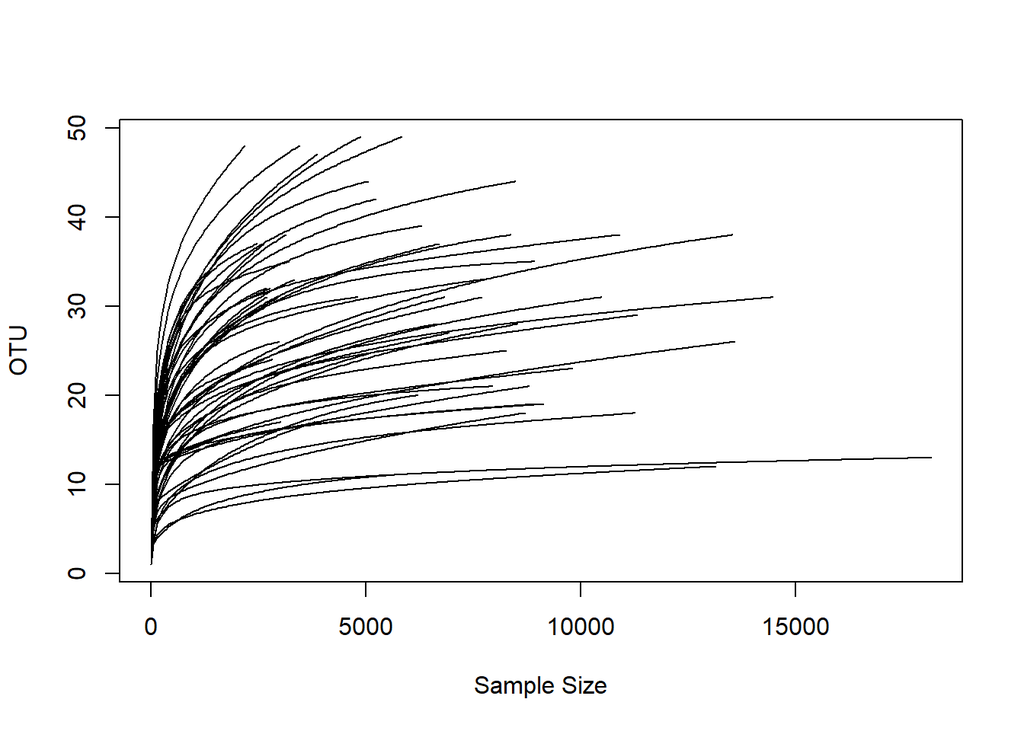

```r
# Rarefaction curves
otu_tab_nifH <- otu_table(nifH_gbs)
class(otu_tab_nifH) <- "matrix" # as.matrix() will do nothing
## you get a warning here, but this is what we need to have
otu_tab_nifH <- t(otu_tab_nifH) # transpose observations to rows

rare <- rarecurve(otu_tab_nifH, step=50, lwd=1, ylab="OTU",  label=F)
```

```r
sample_sums(nifH_gbs)
```

```
## JC2790 JC2791 JC2792 JC2793 JC2794 JC2795 JC2796 JC2797 JC2798 JC2800 JC2801
##   1436  13125   8923   3205   6701   2979   2689   5834   1369  13524   2960
## JC2802 JC2803 JC2804 JC2805 JC2806 JC2807 JC2926 JC2927 JC2929 JC2930 JC2933
##  10475   4796   6204   5303   4867  10906   8699  13575   6817   7691   9133
## JC2937 JC2938 JC2939 JC2940 JC2943 JC2944 JC2945 JC2947 JC2948 JC2949 JC2950
##   5225   3336   6289   7942   2625   8255   2671   9799   8927   8798   3867
## JC2951 JC2952 JC2953 JC2955 JC2956 JC2958 JC2959 JC2960 JC2961 JC2962 JC2963
##   8518  14466   6931   3805   2811  11300   2459   6638   8363   3016   8480
## JC3085 JC3086 JC3087 JC3088 JC3089 JC3090 JC3210 JC3212 JC3214
##   2186   3455   2772   7727   3138  11249   5509   5046  18143
```

```r
# Rarefied data without replacement
set.seed(1)
ps.rarefied_nifH_gbs <- rarefy_even_depth(nifH_gbs, rngseed=1, sample.size=0.9*min(sample_sums(nifH_gbs)), replace=F)
```

```
## `set.seed(1)` was used to initialize repeatable random subsampling.
```

```
## Please record this for your records so others can reproduce.
```

```
## Try `set.seed(1); .Random.seed` for the full vector
```

```
## ...
```

```
## 3OTUs were removed because they are no longer
## present in any sample after random subsampling
```

```
## ...
```

```r
# Check the number of sequences per sample
sample_sums(ps.rarefied_nifH_gbs)
```

```
## JC2790 JC2791 JC2792 JC2793 JC2794 JC2795 JC2796 JC2797 JC2798 JC2800 JC2801
##   1232   1232   1232   1232   1232   1232   1232   1232   1232   1232   1232
## JC2802 JC2803 JC2804 JC2805 JC2806 JC2807 JC2926 JC2927 JC2929 JC2930 JC2933
##   1232   1232   1232   1232   1232   1232   1232   1232   1232   1232   1232
## JC2937 JC2938 JC2939 JC2940 JC2943 JC2944 JC2945 JC2947 JC2948 JC2949 JC2950
##   1232   1232   1232   1232   1232   1232   1232   1232   1232   1232   1232
## JC2951 JC2952 JC2953 JC2955 JC2956 JC2958 JC2959 JC2960 JC2961 JC2962 JC2963
##   1232   1232   1232   1232   1232   1232   1232   1232   1232   1232   1232
## JC3085 JC3086 JC3087 JC3088 JC3089 JC3090 JC3210 JC3212 JC3214
##   1232   1232   1232   1232   1232   1232   1232   1232   1232
```

## 2.2 Alpha diversity estimates

```r
# Diversity indexes. Disbale phangorn or will not recognize the function.
Shannon.nifH <- diversity(t(otu_table(ps.rarefied_nifH_gbs)), index = "shannon")
Simpson.nifH <- diversity(t(otu_table(ps.rarefied_nifH_gbs)), index = "simpson")
Pielou.nifH <- Shannon.nifH/log(specnumber(t(otu_table(ps.rarefied_nifH_gbs))))
variables_nifH <- sample_data(ps.rarefied_nifH_gbs)

# Merge into one dataframe
Alpha_nifH <- data.frame(variables_nifH,Shannon.nifH,Simpson.nifH,Pielou.nifH)
names(Alpha_nifH)[names(Alpha_nifH) == "Shannon.nifH"] <- "Shannon"
names(Alpha_nifH)[names(Alpha_nifH) == "Simpson.nifH"] <- "Simpson"
names(Alpha_nifH)[names(Alpha_nifH) == "Pielou.nifH"] <- "Pielou"
Alpha_nifH$Plot <- as.factor(Alpha_nifH$Plot)

# Faith phylogenetic diversity
library(phangorn)
class(rooted_tree_nifH) # Check if the tree is rooted
```

```
## [1] "phylo"
```

```r
getRoot(rooted_tree_nifH)
```

```
## [1] 106
```

```r
Faith_nifH<- pd(t(otu_table(ps.rarefied_nifH_gbs)),rooted_tree_nifH,include.root=F)
Alpha_nifH <-data.frame(Alpha_nifH,Faith_nifH)
names(Alpha_nifH)[names(Alpha_nifH) == "PD"] <- "Faith"
names(Alpha_nifH)[names(Alpha_nifH) == "SR"] <- "Observed"

# Check the number of samples per category
table(Alpha_nifH$Habitat,Alpha_nifH$Genotype)
```

```
##
##                 AB CD
##   Forest tundra 12 19
##   Shrub tundra   7 15
```

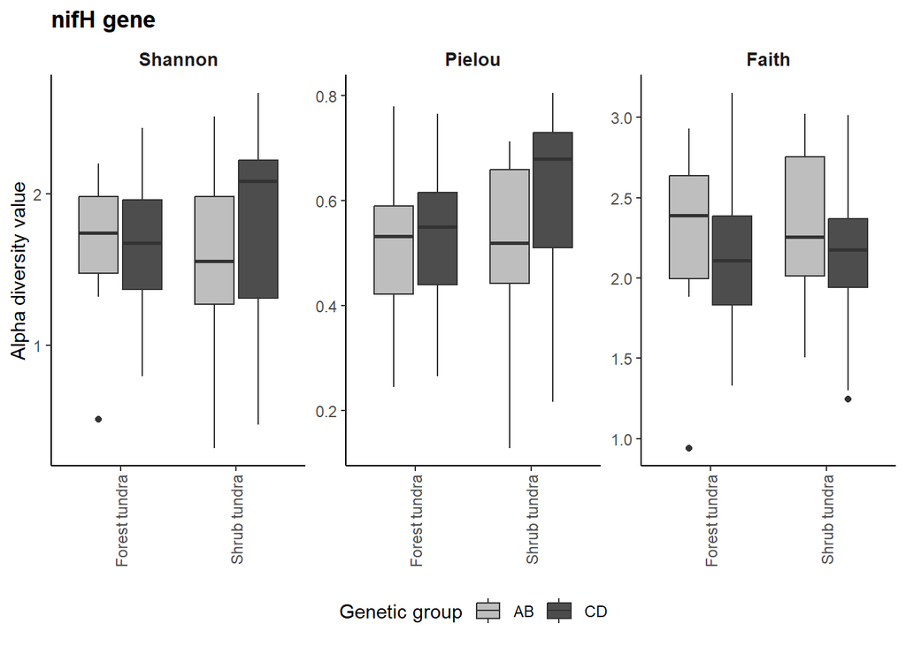

```r
# Manipulate data
data_long_nifH_gen <- Alpha_nifH %>%
  pivot_longer(cols = c(Shannon,Pielou,Faith),
               names_to = "Alpha_Index",
               values_to = "Alpha_Value")

# Order levels
data_long_nifH_gen$Alpha_Index<-factor(data_long_nifH_gen$Alpha_Index, levels = c("Shannon", "Pielou","Faith"))

# Create plot
Plot_alpha_GBS_nifH <- ggplot(data_long_nifH_gen , aes(x = Habitat, y = Alpha_Value, fill = Genotype)) +
  geom_boxplot() +
  facet_wrap(~ Alpha_Index, scales = "free_y") +
  labs(title = "nifH gene",
       x = NULL,
       y = "Alpha diversity value",
       fill = "Genetic group") +
  scale_fill_manual(values=c("gray","#4d4d4d")) +
  theme(legend.position = "bottom",  # Placing legend at the bottom
        plot.title = element_text(face= "bold"),  # Centering plot title
        panel.grid.major = element_blank(),  # Remove major grid lines
        panel.grid.minor = element_blank(),
        panel.background = element_blank(),
        panel.border = element_blank(),
        axis.line = element_line(colour = "black"),
        axis.line.x.top = element_line(colour = "black"),
        strip.text = element_text(size=10, face= "bold"),
        strip.background=element_rect(colour="white", fill = NA),
        axis.text.x = element_text(angle = 90, vjust = 0.5, hjust=1))

Plot_alpha_GBS_nifH
```

```r
# ggsave("Figure_3_Alpha_diversity_nifH_Gen_habitat_rarefied.tiff", units="mm", width=160, height=150, dpi=300, compression = "lzw")
```

## 2.3 Effect of variables on alpha diversity (Linear Mixed Models)

We can evaluate the effect of Habitat and Genetic group, an their interaction on alpha diversity while accounting for potential random effects.

If the normality of residuals is not respected, we could try LMM or GLMM.

```r
# 1. Choosing the GLMM family
# Since alpha diversity indices (e.g., Shannon, Simpson) are continuous variables, you can use:
# - Gaussian (normal) distribution with identity link (if residuals are normal).
# - Gamma or inverse Gaussian if data is right-skewed.
# - Poisson or negative binomial for count-based indices (e.g., Observed richness).

# 2. Running the LMMs (Linear Mixed Models)
library(lme4)
library(lmerTest)

# Models
lmm_Shannon <- lmer(Shannon ~ Habitat * Genotype + (1 | Plot), data = Alpha_nifH)
lmm_Pielou <- lmer(Pielou ~ Habitat * Genotype + (1 | Plot), data = Alpha_nifH)
lmm_Faith <- lmer(Faith ~ Habitat * Genotype + (1 | Plot), data = Alpha_nifH)

# Checking the model summary
summary(lmm_Shannon)
```

```
## Linear mixed model fit by REML. t-tests use Satterthwaite's method [
## lmerModLmerTest]
## Formula: Shannon ~ Habitat * Genotype + (1 | Plot)
##    Data: Alpha_nifH
##
## REML criterion at convergence: 83
##
## Scaled residuals:
##      Min       1Q   Median       3Q      Max
## -2.00291 -0.32075  0.04702  0.51054  1.22155
##
## Random effects:
##  Groups   Name        Variance Std.Dev.
##  Plot     (Intercept) 0.1938   0.4402
##  Residual             0.1445   0.3802
## Number of obs: 53, groups:  Plot, 24
##
## Fixed effects:
##                                Estimate Std. Error       df t value Pr(>|t|)
## (Intercept)                     1.61984    0.17338 36.94734   9.343 2.87e-11
## HabitatShrub tundra             0.09399    0.27978 40.17915   0.336    0.739
## GenotypeCD                     -0.02449    0.17276 38.76063  -0.142    0.888
## HabitatShrub tundra:GenotypeCD  0.05401    0.27142 36.62610   0.199    0.843
##
## (Intercept)                    ***
## HabitatShrub tundra
## GenotypeCD
## HabitatShrub tundra:GenotypeCD
## ---
## Signif. codes:  0 '***' 0.001 '**' 0.01 '*' 0.05 '.' 0.1 ' ' 1
##
## Correlation of Fixed Effects:
##             (Intr) HbttSt GntyCD
## HbttShrbtnd -0.620
## GenotypeCD  -0.605  0.375
## HbttStn:GCD  0.385 -0.646 -0.636
```

```r
summary(lmm_Pielou)
```

```
## Linear mixed model fit by REML. t-tests use Satterthwaite's method [
## lmerModLmerTest]
## Formula: Pielou ~ Habitat * Genotype + (1 | Plot)
##    Data: Alpha_nifH
##
## REML criterion at convergence: -38.5
##
## Scaled residuals:
##     Min      1Q  Median      3Q     Max
## -2.0831 -0.2391  0.1615  0.5987  1.2618
##
## Random effects:
##  Groups   Name        Variance Std.Dev.
##  Plot     (Intercept) 0.01525  0.1235
##  Residual             0.01245  0.1116
## Number of obs: 53, groups:  Plot, 24
##
## Fixed effects:
##                                 Estimate Std. Error        df t value Pr(>|t|)
## (Intercept)                     0.520851   0.049720 36.441398  10.476 1.53e-12
## HabitatShrub tundra             0.041104   0.080363 39.859547   0.511    0.612
## GenotypeCD                     -0.002028   0.050370 38.670618  -0.040    0.968
## HabitatShrub tundra:GenotypeCD  0.029159   0.079220 36.403665   0.368    0.715
##
## (Intercept)                    ***
## HabitatShrub tundra
## GenotypeCD
## HabitatShrub tundra:GenotypeCD
## ---
## Signif. codes:  0 '***' 0.001 '**' 0.01 '*' 0.05 '.' 0.1 ' ' 1
##
## Correlation of Fixed Effects:
##             (Intr) HbttSt GntyCD
## HbttShrbtnd -0.619
## GenotypeCD  -0.615  0.380
## HbttStn:GCD  0.391 -0.656 -0.636
```

```r
summary(lmm_Faith )
```

```
## Linear mixed model fit by REML. t-tests use Satterthwaite's method [
## lmerModLmerTest]
## Formula: Faith ~ Habitat * Genotype + (1 | Plot)
##    Data: Alpha_nifH
##
## REML criterion at convergence: 70.5
##
## Scaled residuals:
##      Min       1Q   Median       3Q      Max
## -1.76859 -0.44687 -0.07352  0.49883  1.46323
##
## Random effects:
##  Groups   Name        Variance Std.Dev.
##  Plot     (Intercept) 0.1722   0.4150
##  Residual             0.1047   0.3235
## Number of obs: 53, groups:  Plot, 24
##
## Fixed effects:
##                                Estimate Std. Error       df t value Pr(>|t|)
## (Intercept)                     2.17311    0.15590 35.67728  13.939 5.25e-16
## HabitatShrub tundra             0.18615    0.25065 38.90587   0.743    0.462
## GenotypeCD                     -0.09138    0.14914 36.95745  -0.613    0.544
## HabitatShrub tundra:GenotypeCD -0.11346    0.23376 34.87360  -0.485    0.630
##
## (Intercept)                    ***
## HabitatShrub tundra
## GenotypeCD
## HabitatShrub tundra:GenotypeCD
## ---
## Signif. codes:  0 '***' 0.001 '**' 0.01 '*' 0.05 '.' 0.1 ' ' 1
##
## Correlation of Fixed Effects:
##             (Intr) HbttSt GntyCD
## HbttShrbtnd -0.622
## GenotypeCD  -0.581  0.361
## HbttStn:GCD  0.370 -0.621 -0.638
```

```r
# Load the DHARMa package
# install.packages("DHARMa")  # If not installed
library(DHARMa)
```

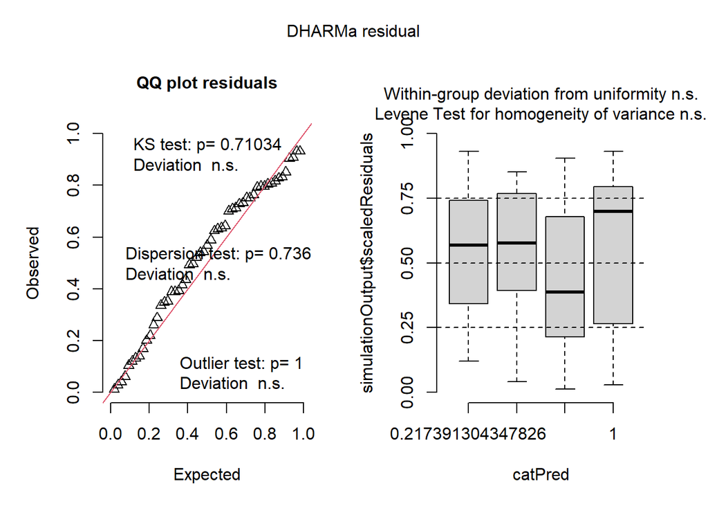

```r
#  p > 0.05 indicates normality
#  p > 0.05 means variance is equal

# Shannon
res_lmm_Shannon <- simulateResiduals(lmm_Shannon)
plot(res_lmm_Shannon)
```

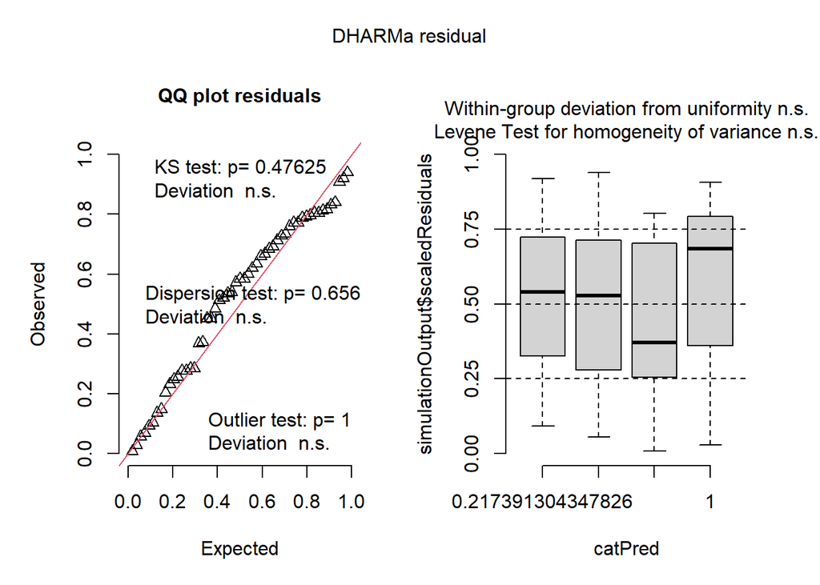

```r
# Pielou
res_lmm_Pielou <- simulateResiduals(lmm_Pielou)
plot(res_lmm_Pielou)
```

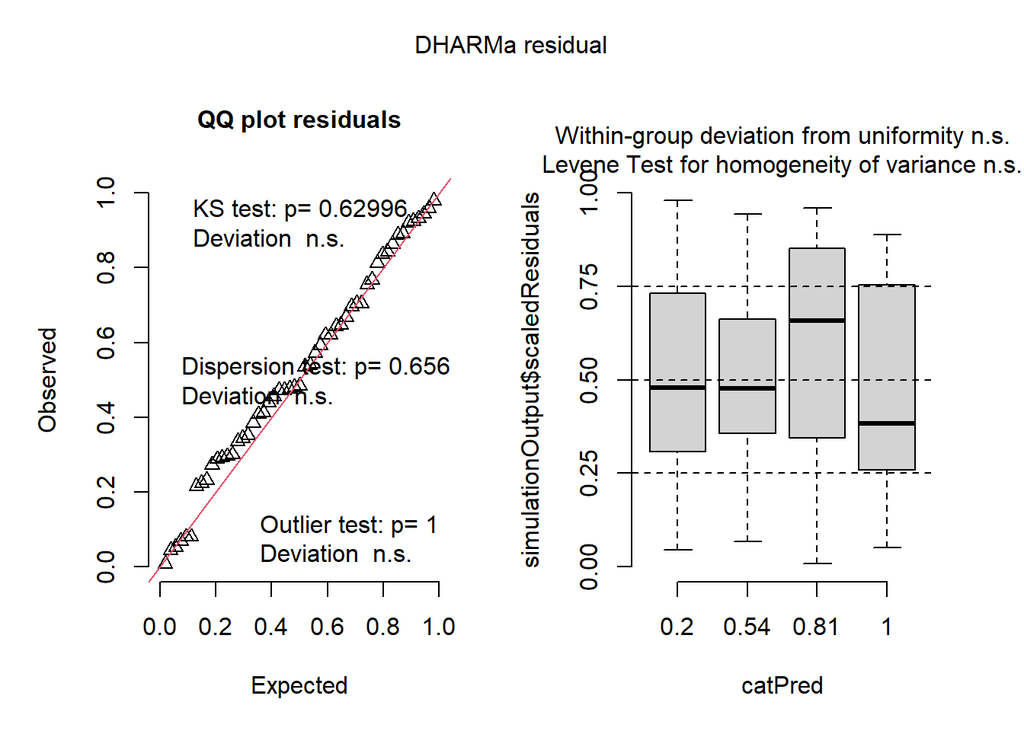

```r
# Faith
res_lmm_Faith <- simulateResiduals(lmm_Faith)
plot(res_lmm_Faith)
```

```r
# Key assumption checks
# The residuals should follow a uniform distribution.
# If deviations exist, consider non-Gaussian families.
# testUniformity(res_lmm_Shannon) # Example

# Dispersion Test (Overdispersion)
# Detects if variance is higher than expected.
# Overdispersion suggests a negative binomial or quasi-Poisson model may be better.
# testDispersion(res_lmm_Shannon) # Example

# Check Overall Significan with ANOVA
anova(lmm_Shannon)
```

|  | Sum Sq | Mean Sq | NumDF | DenDF | F value | Pr(>F) |
| --- | --- | --- | --- | --- | --- | --- |
| Habitat | 0.0444040848 | 0.0444040848 | 1 | 21.53139 | 0.3072556419 | 0.5850812 |
| Genotype | 0.0000496575 | 0.0000496575 | 1 | 36.62610 | 0.0003436068 | 0.9853114 |
| Habitat:Genotype | 0.0057229119 | 0.0057229119 | 1 | 36.62610 | 0.0395998919 | 0.8433655 |

```r
anova(lmm_Pielou)
```

|  | Sum Sq | Mean Sq | NumDF | DenDF | F value | Pr(>F) |
| --- | --- | --- | --- | --- | --- | --- |
| Habitat | 0.010025991 | 0.010025991 | 1 | 20.37764 | 0.8052782 | 0.3800002 |
| Genotype | 0.001250201 | 0.001250201 | 1 | 36.40366 | 0.1004150 | 0.7531424 |
| Habitat:Genotype | 0.001686800 | 0.001686800 | 1 | 36.40366 | 0.1354822 | 0.7149460 |

```r
anova(lmm_Faith)
```

|  | Sum Sq | Mean Sq | NumDF | DenDF | F value | Pr(>F) |
| --- | --- | --- | --- | --- | --- | --- |
| Habitat | 0.04374310 | 0.04374310 | 1 | 21.11591 | 0.4179723 | 0.5249160 |
| Genotype | 0.16805892 | 0.16805892 | 1 | 34.87360 | 1.6058299 | 0.2134762 |
| Habitat:Genotype | 0.02465784 | 0.02465784 | 1 | 34.87360 | 0.2356096 | 0.6304309 |

# 3. Microbial profiling

For diazotrophic profiles, we use the non-rarefied OTU table. In order to plot the bacterial profile, we need to change the format of the data.

```r
# Transform to relative abundance
nifH_gbs.ra<- transform_sample_counts(nifH_gbs, function(x){x / sum(x)})
# taxa_sums(nifH_gbs.ra)


# Format the data
phylo_nifH.ra_table <- psmelt(nifH_gbs.ra)
```

```r
# Calculate total relative abundance for each Phylum. This will result in more than 1.00 per phylum because it sums the relative abundance per sample not per Phylum.
phylum_abundance_2 <- aggregate(Abundance ~ Phylum, data = phylo_nifH.ra_table, FUN = sum)
# Insert a column of the relative abundance per Phylum
phylum_abundance_2 <- mutate(phylum_abundance_2,percent = Abundance / sum(Abundance))

# Check the total abundance and percentage
sum(phylum_abundance_2$Abundance)
```

```
## [1] 53
```

```r
sum(phylum_abundance_2$percent)
```

```
## [1] 1
```

```r
# Identify Phyla with less than 0.01% abundance
low_abundance_phyla_2 <- phylum_abundance_2$Phylum[phylum_abundance_2$percent < 0.01]

# Group Phyla with less than 0.01% abundance as "Other (<0.01%)"
phylo_nifH.ra_table$Grouped_Phylum <- ifelse(phylo_nifH.ra_table$Phylum %in% low_abundance_phyla_2, "Other", phylo_nifH.ra_table$Phylum)

phylo_nifH.ra_table$Grouped_Phylum <-as.factor(phylo_nifH.ra_table$Grouped_Phylum)

# Calculate total abundance for each grouped Phylum
grouped_phylum_abundance_2 <- aggregate(Abundance ~ Grouped_Phylum, data = phylo_nifH.ra_table, FUN = sum)

# Reorder levels of Grouped_Phylum based on abundance
phylo_nifH.ra_table$Grouped_Phylum <- factor(phylo_nifH.ra_table$Grouped_Phylum,
                                              levels = grouped_phylum_abundance_2$Grouped_Phylum[order(desc(grouped_phylum_abundance_2$Abundance))])

# Reorder Phyla< 0.01
phylo_nifH.ra_table$Grouped_Phylum <- relevel(phylo_nifH.ra_table$Grouped_Phylum,
                                                        "Other")
```

We plot the most abundant phyla

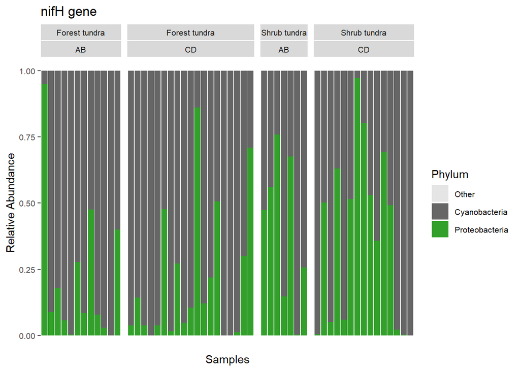

```r
# Plot relative abundance per Phylum
BarPlot_nifH_GBS_phylum <- phylo_nifH.ra_table %>%
  ggplot(aes(x = Sample, y = Abundance, fill = Grouped_Phylum)) +
  geom_bar(stat = "identity", position="stack") +
  labs(x = "Samples",
       y = "Relative Abundance",title= "nifH gene",fill = "Phylum") +
  facet_grid(~ Habitat + Genotype, scales = "free", space='free') +
  theme_bw()+
  scale_fill_manual(values=Contrasting_palette_1)+
  theme(
    axis.text.y = element_text(size = 8,),
    axis.text.x = element_blank(),
    legend.text = element_text(size = 8),
    strip.text = element_text(size = 8),
    panel.background = element_blank(),
    panel.border = element_blank(),
    axis.ticks.x = element_blank(),
    panel.grid.major = element_blank(),panel.grid.minor = element_blank(),
    strip.background=element_rect(colour="white")
  )

BarPlot_nifH_GBS_phylum
```

```r
# ggsave("Figure_Microbial_profile_Genotype_nifH_Phylum.tiff", units="mm", width=180, height=120, dpi=150, compression = "lzw")
```

Now, we can find the most abundant genera with a similar analysis.

```r
# Calculate total relative abundance for each Genus. This will result in more than 1.00 per genus because it sums the relative abundance per sample not per Genus.
genus_abundance_4 <- aggregate(Abundance ~ Genus, data = phylo_nifH.ra_table, FUN = sum)

# Insert a column of the total relative abundance per Genus
genus_abundance_4 <- mutate(genus_abundance_4, percent = Abundance / sum(Abundance))

# Total OTU counts
sum(genus_abundance_4$Abundance)
```

```
## [1] 53
```

```r
# Total relative abundance of all genera. Should be 1.
sum(genus_abundance_4$percent)
```

```
## [1] 1
```

```r
# Identify the top 20 most abundant genera
top_20_genera_Moss_nifH <- genus_abundance_4 %>%
  arrange(desc(Abundance)) %>%
  head(20) %>%
  pull(Genus)

# Reorder levels of Grouped_Genus based on abundance
phylo_nifH.ra_table$Genus <- factor(phylo_nifH.ra_table$Genus,
                                             levels = genus_abundance_4$Genus[order(desc(genus_abundance_4$Abundance))])

# Subgroup to obtain relative abundance per group
ps_rare_moss_nifH.ra_table_Samples <-phylo_nifH.ra_table %>%
  group_by(Habitat, Genotype) %>%
  mutate(Abundance = Abundance / sum(Abundance))
```

We plot the most abundant bacterial genera.

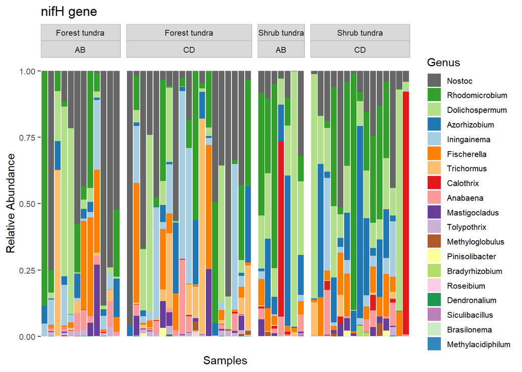

```r
# Produce the plot
BarPlot_nifH_GBS_genus <- phylo_nifH.ra_table %>%
  ggplot(aes(x = Sample, y = Abundance, fill = Genus)) +
  geom_bar(stat = "identity", position="stack") +
  labs(x = "Samples",
       y = "Relative Abundance",title = "nifH gene", fill = "Genus") +
  facet_grid(~ Habitat + Genotype, scales = "free", space='free') +
  theme_bw()+
  scale_fill_manual(values=Contrasting_palette_2)+
  theme(
    axis.text.y = element_text(size = 8,),
    axis.text.x = element_blank(),
    legend.key.size = unit(0.5, 'cm'),
    legend.text = element_text(size = 8),
    legend.justification.right = c(0,0.5),
    strip.text = element_text(size = 8),
    panel.background = element_blank(),
    panel.border = element_blank(),
    axis.ticks.x = element_blank(),
    panel.grid.major = element_blank(),panel.grid.minor = element_blank(),
    strip.background=element_rect(colour="gray"),
  ) + guides(fill=guide_legend(ncol =1))

BarPlot_nifH_GBS_genus
```

```r
# ggsave("Figure_1-1_Relative_abundance_moss_Genotype_Habitat_Genus_nifH.tiff", units="mm", width=230, height=200, dpi=300, compression = "lzw")
```

We could present the same bar plot by pooling all the samples per habitat and genetic group

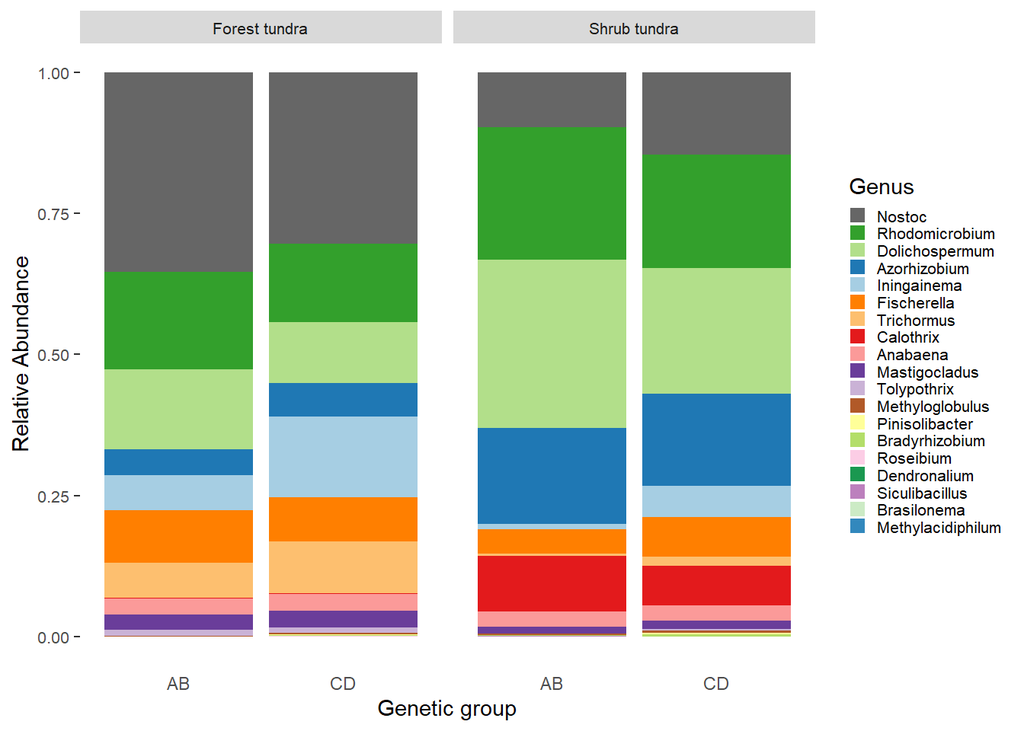

```r
# Plot the mean per habitat and genetic group

# Subgroup to obtain relative abundance per group
phylo_nifH.ra_table_Samples_Habitat_Genetic <-phylo_nifH.ra_table %>%
  group_by(Habitat,Genotype) %>%
  mutate(Abundance = Abundance / sum(Abundance))

# Produce the plot
BarPlot_nifH_GBS_genus_Genotype <- phylo_nifH.ra_table_Samples_Habitat_Genetic  %>%
  ggplot(aes(x = Genotype, y = Abundance, fill = Genus)) +
  geom_bar(stat = "identity", position="stack") +
  labs(x = "Genetic group",
       y = "Relative Abundance",fill = "Genus") +
  facet_grid(~ Habitat, scales = "free", space='free') +
  theme_bw()+
  scale_fill_manual(values=Contrasting_palette_2)+
  theme(
    axis.text.y = element_text(size = 8,),
    legend.text = element_text(size = 8),
    legend.justification.right = c(0,0.5),
    strip.text = element_text(size = 8),
    legend.key.size = unit(0.3, 'cm'),
    panel.background = element_blank(),
    panel.border = element_blank(),
    axis.ticks.x = element_blank(),
    panel.grid.major = element_blank(),panel.grid.minor = element_blank(),
    strip.background=element_rect(colour=NA),
    #strip.placement = "outside",
  ) + guides(fill=guide_legend(ncol =1))

BarPlot_nifH_GBS_genus_Genotype
```

```r
# To put the strips in the bottom use switch = "x"
# ggsave("Figure_1-2_Relative_abundance_moss_pooled_Genotype_Habitat_Genus_nifH.tiff", units="mm", width=230, height=200, dpi=300, compression = "lzw")
```